# Final Sedentary-Time Analysis

Christopher Odoom

2026-06-29

## Purpose

This R Markdown file documents and reproduces the manuscript analysis for estimating waking sedentary time in NHANES 2011-2014 wrist accelerometer data. The project combines posture predictions from the CHAP wrist model with sleep/nonwear information from SWaN to estimate each participant’s usual daily waking sedentary time.

The main goal is to produce survey-weighted, nationally representative estimates of waking sedentary time after excluding sleep/nonwear periods. The analysis calibrates a sleep/nonwear percentage cutoff against NHANES self-reported sleep duration, applies the selected cutoff at the primary analysis epoch, summarizes sedentary time to the participant level, and estimates overall and subgroup means using the NHANES survey design.

This file is also a reproducibility driver. It reads the analysis-ready accelerometer datasets from the `wristsed` data package, derives the analytic sample, recalibrates the sleep cutoff for the 1-hour SWaN primary analysis, generates manuscript tables and figures, and writes final outputs to `outputs/final_analysis/` and `figures/final_analysis/`.

## Analysis Configuration

The primary render uses the 1-hour SWaN epoch dataset. Sleep/nonwear removal is applied at the epoch level before participant-day sedentary totals are calculated. For figures that display hourly patterns, records are aggregated to hour only after the sleep/nonwear rule has been applied.

The primary analytic unit is the NHANES participant. Epoch-level accelerometer records are used to construct participant-day and participant-level sedentary time summaries, but survey-weighted estimation is performed at the participant level to avoid giving participants with more observed records or more valid days disproportionate influence.

## Self-Reported Sleep Benchmark

NHANES self-reported sleep duration is used as an external benchmark for selecting the accelerometer sleep/nonwear cutoff. The benchmark is estimated with the same combined 2011-2014 survey design used for the primary participant analysis.

## Primary 1-Hour Cutoff And Participant Data

The final sleep/nonwear cutoff is selected from a fine-resolution objective curve. For each candidate cutoff, the analysis compares survey-weighted accelerometer-derived sleep/nonwear duration with the survey-weighted NHANES self-reported sleep benchmark. The selected cutoff is the value that minimizes the absolute difference between those two sleep-duration estimates. This fine-resolution selected cutoff, not the coarse sensitivity-grid cutoff, is used for the primary waking sedentary-time analysis.

The fine-resolution objective curve selected a 1-hour SWaN sleep/nonwear cutoff of 90.84%. At this cutoff, the survey-weighted accelerometer-derived sleep/nonwear estimate was 6.91 hours/day, and the absolute difference from the survey-weighted self-reported sleep benchmark was 0.043 hours/day.

## Main Estimates

Survey-weighted estimates are computed at the participant level. Each participant contributes one usual daily waking sedentary-time estimate, one waking-time estimate, and one sleep/nonwear-time estimate to the survey design.

Primary SWaN 1-hour survey-weighted estimates.

| Measure | Mean (h/day) | SE | 95% CI lower | 95% CI upper |
| --- | --- | --- | --- | --- |
| Waking sedentary time | 11.35 | 0.04 | 11.26 | 11.44 |
| Waking time | 17.09 | 0.05 | 16.99 | 17.19 |
| Sleep/nonwear time | 6.91 | 0.05 | 6.81 | 7.01 |
| Self-reported sleep time | 6.95 | 0.02 | 6.92 | 6.99 |

Main survey-weighted estimates overall and by NHANES cycle.

| Analysis group | Measure | Mean (h/day) | SE | 95% CI |
| --- | --- | --- | --- | --- |
| Pooled | Mean sedentary time | 11.35 | 0.04 | 11.26-11.44 |
| Pooled | Waking time | 17.09 | 0.05 | 16.99-17.19 |
| Pooled | Sleep/non-wear time | 6.91 | 0.05 | 6.81-7.01 |
| 2011-2012 cycle | Mean sedentary time | 11.46 | 0.06 | 11.34-11.58 |
| 2011-2012 cycle | Waking time | 17.27 | 0.07 | 17.14-17.40 |
| 2011-2012 cycle | Sleep/non-wear time | 6.73 | 0.07 | 6.60-6.86 |
| 2013-2014 cycle | Mean sedentary time | 11.25 | 0.07 | 11.12-11.37 |
| 2013-2014 cycle | Waking time | 16.92 | 0.08 | 16.76-17.08 |
| 2013-2014 cycle | Sleep/non-wear time | 7.08 | 0.08 | 6.92-7.24 |

Note. Estimates are survey-weighted and expressed in hours per day. SE = standard error; CI = confidence interval. Pooled estimates combine the 2011-2012 and 2013-2014 NHANES cycles using recalibrated 4-year examination weights.

### Justification for Combining Survey Cycles

To assess whether the two NHANES cycles could be pooled, we compared survey-weighted estimates of mean sedentary time between 2011-2012 and 2013-2014. The mean sedentary time was 11.46 hours/day (SE = 0.06) in 2011-2012 and 11.25 hours/day (SE = 0.07) in 2013-2014. The survey-weighted regression estimate of the difference was -0.21 hours/day (p = 0.0251). This difference is small relative to the overall mean, so the two cycles were combined for subsequent analyses using recalibrated 4-year examination weights.

### NHANES Analytic Approach

The primary estimand in this manuscript is the population mean of each participant’s usual daily waking sedentary time. The analysis therefore treats the NHANES sample person, not the hour, as the survey-weighted analytic unit. This matches NHANES guidance: sample weights are assigned to sample persons and account for unequal probability of selection, nonresponse, and post-stratification to U.S. population control totals.

The repeated accelerometer records were still used fully to derive the participant-level exposure. For each candidate sleep cutoff, SWaN sleep/nonwear percentages determined whether an epoch was treated as waking time, CHAP sitting probabilities contributed fractional sedentary hours using the epoch duration, daily totals were computed, and valid days were averaged within participant. The person-level mean is therefore a summary of all available epoch- and daily-level information for that participant.

What is intentionally removed before the main survey estimation is the repeated record structure itself, because leaving epochs or days as separate weighted records would give participants with more observed records or valid days more influence than participants with fewer records. That would change the estimand from a population mean across people to a record-weighted mean across observed person-epochs or person-days.

## Table 1

Analytic sample and wear-day distribution by NHANES cycle (2011-2014).

| Full days | 2011-2012 | 2013-2014 | Total (2011-14) |
| --- | --- | --- | --- |
| 1 | 29 (0.4) | 32 (0.4) | 61 (0.4) |
| 2 | 37 (0.5) | 31 (0.4) | 68 (0.5) |
| 3 | 48 (0.7) | 30 (0.4) | 78 (0.5) |
| 4 | 37 (0.5) | 30 (0.4) | 67 (0.5) |
| 5 | 56 (0.8) | 30 (0.4) | 86 (0.6) |
| 6 | 68 (1.0) | 43 (0.6) | 111 (0.8) |
| 7 | 6,606 (96.0) | 7,531 (97.5) | 14,137 (96.8) |
| Sample Analyzed (1-7) | 6,881 (100.0) | 7,727 (100.0) | 14,608 (100.0) |

Notes: A full day is a 24-hour day represented by 24 hourly records; partial initiation and return days are excluded.

## Epoch Sensitivity Table

Epoch-level sensitivity analysis by sleep/wake detection algorithm.

| Method | Row | Cutoff | Sedentary | Waking | Sleep/nonwear |
| --- | --- | --- | --- | --- | --- |
| SWaN | Direct states | - | 6.52 (0.04) | 12.09 (0.06) | 11.91 (0.06) |
| SWaN | 10m epoch | 90.01 | 10.91 (0.05) | 16.66 (0.06) | 7.34 (0.06) |
| SWaN | 30m epoch | 91.67 | 11.39 (0.05) | 17.13 (0.06) | 6.87 (0.06) |
| SWaN | 1h epoch | 90.84 | 11.35 (0.04) | 17.09 (0.05) | 6.91 (0.05) |
| NHANES | Direct states | - | 7.97 (0.04) | 13.66 (0.06) | 9.48 (0.06) |
| NHANES | 10m epoch | 90.01 | 11.05 (0.05) | 16.79 (0.06) | 7.21 (0.06) |
| NHANES | 30m epoch | 86.67 | 11.11 (0.05) | 16.85 (0.06) | 7.15 (0.06) |
| NHANES | 1h epoch | 85.01 | 11.21 (0.05) | 16.94 (0.06) | 7.06 (0.06) |

Notes: Direct states do not apply a sleep/nonwear cutoff. For SWaN, direct states use the underlying SWaN wake, sleep, and non-wear classifications combined with CHAP waking-sedentary time. For NHANES, direct states use the official NHANES 1-minute sleep-state classifications combined with the same CHAP posture summaries. Epoch rows first aggregate sleep/nonwear states to the listed epoch length, then classify each whole epoch as waking when its sleep/nonwear percentage is below the calibrated cutoff; epochs at or above the cutoff are counted as sleep/non-wear.

## Cutoff Sensitivity Grid

This step does not select the final sleep/nonwear cutoff. It evaluates a coarse grid of candidate cutoffs in 5-percentage-point increments to summarize how survey-weighted sleep/nonwear duration and waking sedentary time change across plausible decision rules. The final cutoff used in the primary analysis is the fine-resolution value selected above.

## Demographic Missingness

Demographic, anthropometric, and survey-design variables are taken from the participant-level analysis datasets and reduced to one record per participant before survey estimation. Age is grouped as `<18`, `18-34`, `35-44`, `45-64`, and `>=65` years. Race/ethnicity is retained using the NHANES-coded categories available in the analysis data. BMI is grouped as under/normal weight (`BMI < 25`), overweight (`25 <= BMI < 30`), and obesity (`BMI >= 30`). Participants with missing subgroup information are not recoded into another category; missing values are excluded only from the relevant subgroup/domain estimate.

These variables describe population heterogeneity in waking sedentary time, not repeated epoch-level covariates. Subgroup estimates for age, gender, race/ethnicity, and BMI are calculated from the participant-level survey design object using domain analyses. This preserves the NHANES design information for standard error estimation while estimating the mean for the population domain of interest.

Missingness of demographic and survey design variables relative to the final analytic sample.

| Variable | Analytic sample N | Missing n | Missing % | Available n |
| --- | --- | --- | --- | --- |
| Age group | 14608 | 0 | 0.00 | 14608 |
| BMI category | 14608 | 135 | 0.92 | 14473 |
| Education | 14608 | 0 | 0.00 | 14608 |
| Gender | 14608 | 0 | 0.00 | 14608 |
| Marital status | 14608 | 0 | 0.00 | 14608 |
| Masked PSU | 14608 | 0 | 0.00 | 14608 |
| Masked stratum | 14608 | 0 | 0.00 | 14608 |
| Race/ethnicity | 14608 | 0 | 0.00 | 14608 |
| Recalibrated examination weight | 14608 | 0 | 0.00 | 14608 |

The final analytic sample included 14,608 participants after applying accelerometer-data availability and survey-design requirements. Missingness in demographic and survey-design variables is shown relative to this analytic denominator so subgroup tables can be interpreted with the correct available sample for each domain.

### Overview of Sedentary-Time Estimation

The analysis proceeded in the following steps:

1. **Start with wrist accelerometer data.** We used NHANES 2011-2012 and 2013-2014 wrist accelerometer files.
2. **Prepare the files for prediction models.** The raw files were organized by participant and day and converted into the formats needed by the posture and sleep/wear models upstream of this report.
3. **Identify sitting in 10-second epochs.** The CHAP/DeepPostures model classified each 10-second epoch as sitting or not sitting.
4. **Identify sleep and nonwear.** SWaN classified accelerometer records as wake wear, sleep, or nonwear; these predictions were summarized to the analysis epochs used in this report.
5. **Summarize predictions for analysis.** Epoch-level predictions were converted to epoch-level percentages for the primary analysis.
6. **Choose the sleep/nonwear cutoff.** Candidate cutoffs were evaluated by comparing survey-weighted accelerometer-derived sleep/nonwear duration with NHANES self-reported sleep duration.
7. **Keep only waking epochs for sedentary-time estimation.** Epochs below the selected sleep/nonwear cutoff were treated as waking epochs. Epochs at or above the cutoff were removed from waking sedentary-time estimation.
8. **Calculate sedentary hours for each day.** For each participant-day, sedentary percentages were multiplied by epoch duration and added across waking epochs.
9. **Average days within each participant.** Daily waking sedentary-time values were averaged across each participant’s valid wear days.
10. **Use the NHANES survey design.** Each participant’s usual daily waking sedentary time was analyzed using NHANES examination weights, masked variance strata, and masked primary sampling units.
11. **Estimate national and subgroup values.** Survey-weighted means and confidence intervals were estimated for the full population and for subgroups defined by age, gender, race/ethnicity, and BMI category.

## Figure 1

Workflow for deriving hourly sedentary and sleep/nonwear summaries. (A) Raw 80 Hz accelerometer signal. (B) CHAP sedentary predictions and SWaN sleep/wake/nonwear classifications. (C) Hourly sedentary and sleep/nonwear percentages used to define waking sedentary time under candidate sleep cutoffs.

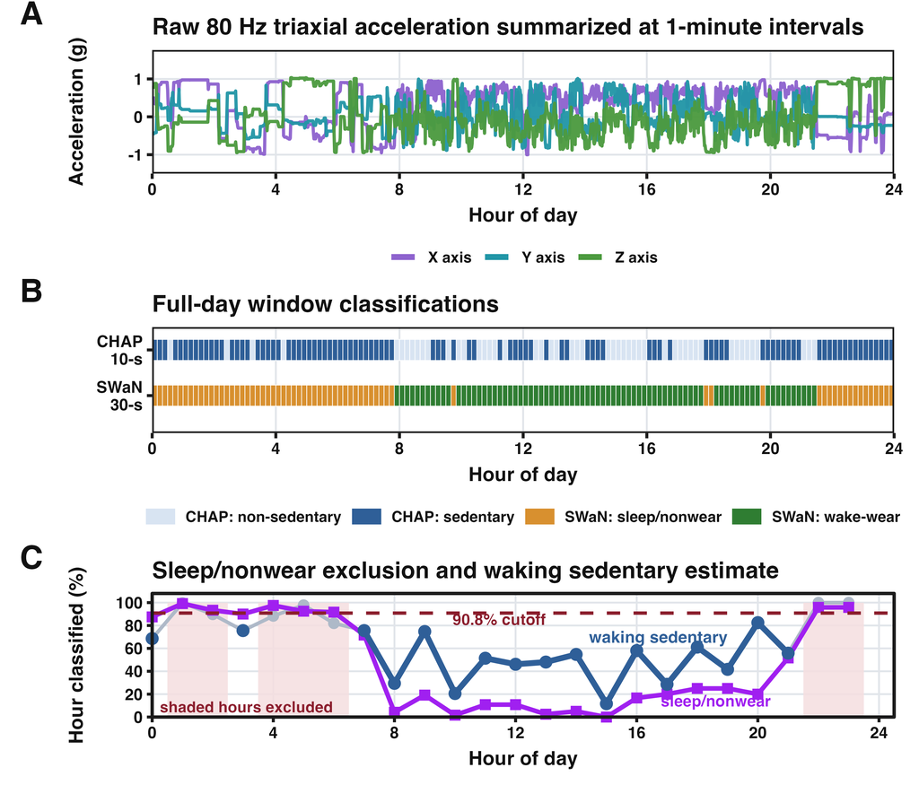

## Table 2

This table places the current wrist-derived estimate beside prior NHANES sedentary-time estimates that used different devices, time periods, populations, or self-report instruments.

Comparison of sedentary time estimates across studies by measurement method, datasets, and population.

[output not shown]

## Figure 2

Survey-weighted hourly patterns of wrist-derived waking sedentary behavior are shown by day type after excluding records with sleep/nonwear greater than or equal to the selected 90.84% cutoff. Lines represent hourly means and shaded bands indicate 95% confidence intervals.

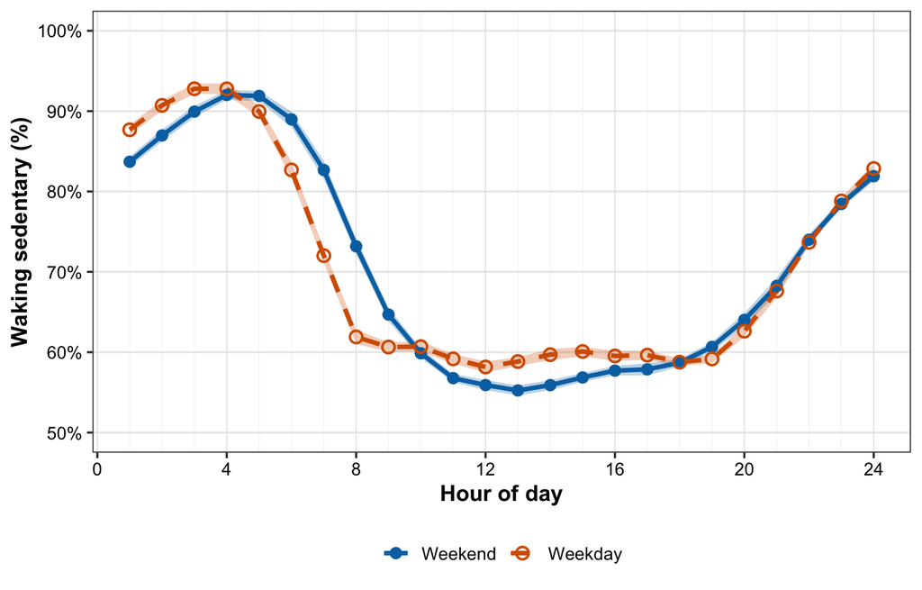

## Figure 3

Distribution of participants by mean daily waking sedentary time and corresponding 24-hour behavioral composition. Panel A shows the proportion and unweighted number of participants in each sedentary-time category. Panel B shows the mean daily allocation to sedentary time, sleep/nonwear, and non-sedentary waking time within each category.

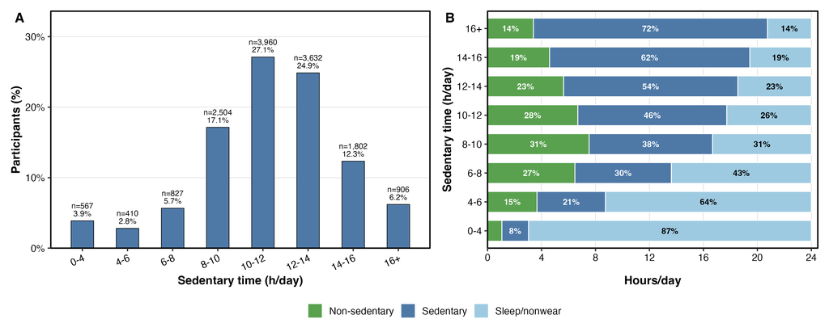

## Table 3

Weighted sedentary behavior by gender and age, United States, 2011-2014.

| Age group | Male n (%) | Male mean (95% CI) | Female n (%) | Female mean (95% CI) |
| --- | --- | --- | --- | --- |
| All ages | 7,142 (48.9%) | 11.48 (11.35, 11.62) | 7,466 (51.1%) | 11.22 (11.12, 11.33) |
| <18 | 2,346 (16.1%) | 10.54 (10.35, 10.73) | 2,255 (15.4%) | 10.20 (10.03, 10.36) |
| 18-34 | 1,454 (10.0%) | 10.88 (10.61, 11.15) | 1,515 (10.4%) | 10.60 (10.33, 10.87) |
| 35-44 | 755 (5.2%) | 11.08 (10.68, 11.48) | 867 (5.9%) | 10.79 (10.52, 11.06) |
| 45-64 | 1,556 (10.7%) | 11.93 (11.72, 12.14) | 1,717 (11.8%) | 11.69 (11.51, 11.86) |
| >=65 | 1,031 (7.1%) | 13.52 (13.33, 13.72) | 1,112 (7.6%) | 12.89 (12.62, 13.15) |

## Table 4

Weighted mean sedentary time by race/ethnicity and BMI category, NHANES 2011-2014.

| Race | Underweight/normal | Overweight | Obesity |
| --- | --- | --- | --- |
| All | 10.78 (10.67, 10.90) | 11.30 (11.15, 11.45) | 12.08 (11.90, 12.26) |
| Mexican American | 10.46 (10.22, 10.71) | 10.35 (10.07, 10.64) | 10.92 (10.68, 11.15) |
| NH Asian | 10.99 (10.75, 11.24) | 11.54 (11.20, 11.88) | 11.80 (11.21, 12.40) |
| NH Black | 11.06 (10.82, 11.31) | 11.67 (11.28, 12.05) | 12.43 (12.06, 12.80) |
| NH White | 10.77 (10.61, 10.93) | 11.43 (11.23, 11.63) | 12.25 (12.01, 12.49) |
| Other Hispanic | 10.46 (10.13, 10.78) | 10.60 (10.22, 10.98) | 11.13 (10.75, 11.50) |
| Other/Multi | 11.02 (10.60, 11.44) | 11.40 (10.32, 12.48) | 13.03 (12.45, 13.61) |

## Table 5

Survey-weighted sedentary time by demographic subgroup, NHANES 2011-2014.

| Subgroup | Category | N (%) | Mean sedentary time (95% CI), hours/day |
| --- | --- | --- | --- |
| Age group | <18 | 4,601 (31.5%) | 10.37 (10.25, 10.49) |
|  | 18-34 | 2,969 (20.3%) | 10.74 (10.51, 10.98) |
|  | 35-44 | 1,622 (11.1%) | 10.93 (10.67, 11.19) |
|  | 45-64 | 3,273 (22.4%) | 11.80 (11.68, 11.93) |
|  | >=65 | 2,143 (14.7%) | 13.17 (12.99, 13.35) |
| Gender | Male | 7,142 (48.9%) | 11.48 (11.35, 11.62) |
|  | Female | 7,466 (51.1%) | 11.22 (11.12, 11.33) |
| Race/ethnicity | Mexican American | 2,174 (14.9%) | 10.61 (10.44, 10.79) |
|  | NH Asian | 1,673 (11.5%) | 11.21 (11.01, 11.41) |
|  | NH Black | 3,628 (24.8%) | 11.73 (11.49, 11.97) |
|  | NH White | 5,117 (35.0%) | 11.45 (11.35, 11.55) |
|  | Other Hispanic | 1,431 (9.8%) | 10.71 (10.46, 10.96) |
|  | Other/Multi | 585 (4.0%) | 11.70 (11.24, 12.16) |
| BMI category | under/normal weight | 6,972 (47.7%) | 10.78 (10.67, 10.90) |
|  | overweight | 3,569 (24.4%) | 11.30 (11.15, 11.45) |
|  | obesity | 3,932 (26.9%) | 12.08 (11.90, 12.26) |

## Sleep Distribution Diagnostic

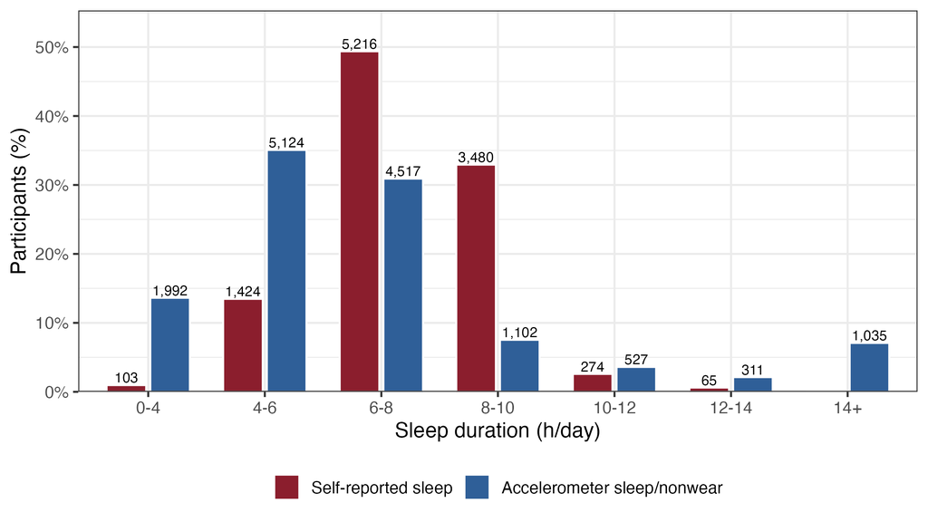

## Figure 4

Sleep-cutoff calibration and sedentary-time sensitivity. Survey-weighted mean accelerometer-derived sleep/nonwear duration and waking sedentary time are shown across candidate sleep-percentage cutoffs. Shaded bands indicate 95% confidence intervals. The vertical dashed line marks the selected 90.84% cutoff, calibrated to the self-reported sleep-duration benchmark.

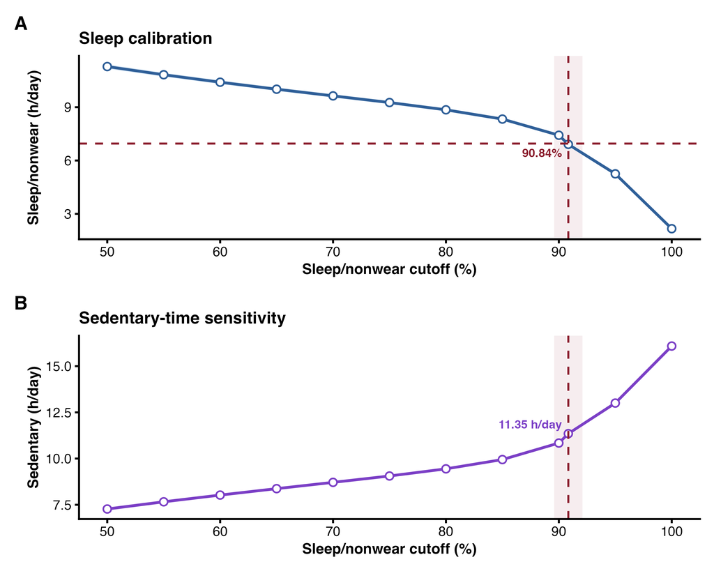

## Output Index

Final analysis outputs.

| Artifact | Path |
| --- | --- |
| Main results | outputs/final_analysis/results/main_results.csv |
| Main results by cycle | outputs/final_analysis/results/main_results_by_cycle.csv |
| Main estimates by cycle table | outputs/final_analysis/results/main_estimates_by_cycle_table.csv |
| Cycle comparison | outputs/final_analysis/results/cycle_comparison.csv |
| Table 1 | outputs/final_analysis/tables/table1_wear_day_distribution.csv |
| Table 2 | outputs/final_analysis/tables/table2_study_comparison.csv |
| Table 3 | outputs/final_analysis/tables/table3_age_gender_sedentary.csv |
| Table 4 | outputs/final_analysis/tables/table4_race_bmi_sedentary.csv |
| Table 5 | outputs/final_analysis/tables/table5_marginal_subgroup_sedentary.csv |
| Epoch sensitivity table | outputs/final_analysis/tables/epoch_sensitivity_table.csv |
| Cutoff sensitivity grid | outputs/final_analysis/cutoff/cutoff_sensitivity_grid.csv |
| Objective curve | outputs/final_analysis/cutoff/objective_curve.csv |
| Selected cutoff | outputs/final_analysis/cutoff/selected_cutoff.csv |
| Demographic missingness | outputs/final_analysis/qc/demographic_missingness.csv |
| Analytic participant dataset | outputs/final_analysis/datasets/analytic_participant_sedentary.csv |
| Figure 1 | figures/final_analysis/fig1_workflow.png |
| Figure 2 | figures/final_analysis/figure2_hourly_waking_sedentary.png |
| Figure 3 | figures/final_analysis/sedentary_distribution_with_24h_composition.png |
| Figure 4 | figures/final_analysis/cutoff_sensi.png |
| Objective diagnostic | figures/final_analysis/objective_function_cutoff.png |
| Sleep distribution diagnostic | figures/final_analysis/sleep_distribution_comparison.png |